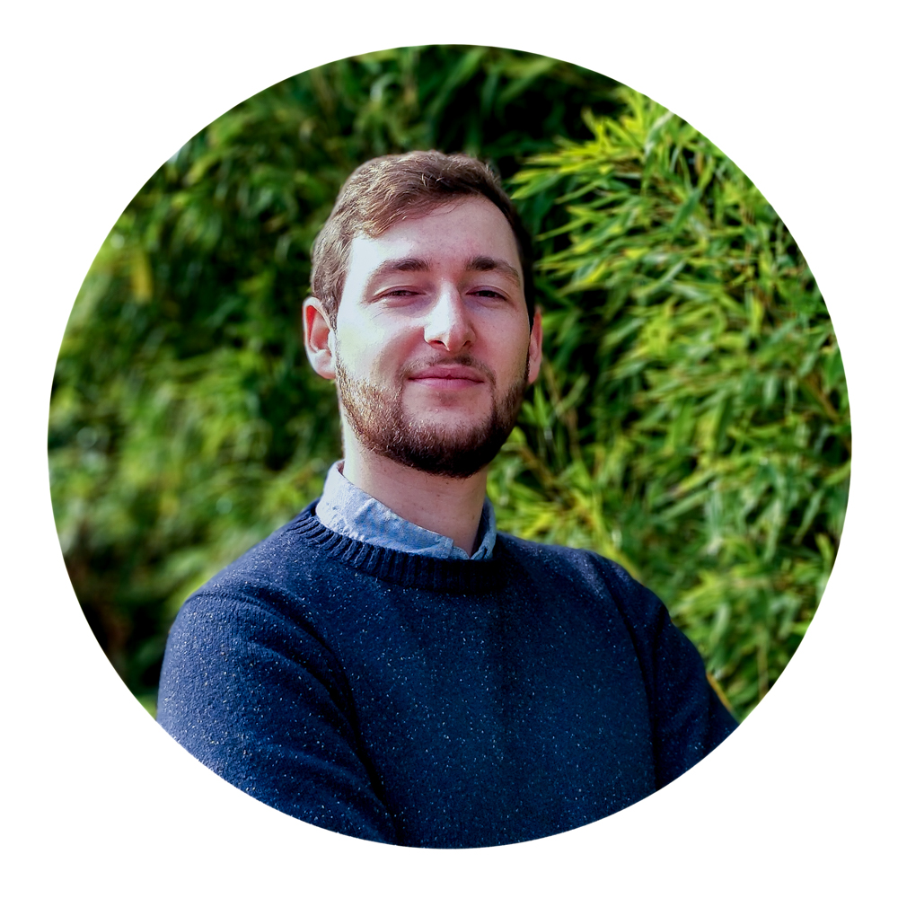

# Felix MIL

## Bio

I’m a 28 years old French living in Paris.

I studied biotechnologies in for health and graduated in 2016 with a [Master Degree](http://www.polytech-angers.fr/fr/index/odf-istia/cycle-ingenieur/ingenieur-biologique-et-sante.html). During my cursus, I had the chance to take part in several project through internships, these experiences allowed me get a precise view of what I wanted to do: *in vitro diagnostic* product development.

After a final and successfull internship in Paris working on nano latex immuno-assays, I was proposed a position as clinical study analyst. This wasn’t a clinical study in pharma terms: the goal was to explore clinical potentials of a new type of optical assay the company developped recently. This was defetively a challenge and a chance to wander on unknown lands. So I took it.

I was in charge of study design, data validation, data analysis. My role wasn’t clear at the begining, so I sticked to what I knew and started bibliography to find relevant clinical applications. I identified one main clinical area where this new assay could be useful: Trauma management. With that, a wide set of variables that I identified as the most promising ones. An impression grew bigger and bigger as I was pursuing this designing phase: I didn’t have the right toolbox to manage all that data efficiently.